# EFA & CFA & OLS: Values

Victoria Bolotova

05 06 2022

# Reading data

```r
library(foreign)
benelux <- read.table("BENELUX_noMissing.dat",  header=F)

names(benelux) <- c("Country","imsmetn","imdfetn","impcntr","gndr","yrbrn","edulvl",
"eduyrs","ipmodst","imptrad","ipfrule","ipbhprp","ipeqopt","ipudrst","impenv")
```

```r
library(dplyr)
efadata <- benelux %>%
  select(imsmetn,imdfetn,impcntr,ipmodst,imptrad,
ipfrule,ipbhprp,ipeqopt,ipudrst,impenv)
```

- imsmetn - ALLOW MANY/FEW IMMIGRANTS OF SAME RACE/ETHNIC GROUP AS MAJORITY
- imdfetn - ALLOW MANY/FEW IMMIGRANTS OF DIFFERENT RACE/ETHNIC GROUP FROM MAJORITY
- impcntr - ALLOW MANY/FEW IMMIGRANTS FROM POORER COUNTRIES OUTSIDE EUROPE
- ipmodst - IMPORTANT TO BE HUMBLE AND MODEST, NOT DRAW ATTENTION
- imptrad - IMPORTANT TO FOLLOW TRADITIONS AND CUSTOMS
- ipfrule - IMPORTANT TO DO WHAT IS TOLD AND FOLLOW RULES
- ipbhprp - IMPORTANT TO BEHAVE PROPERLY
- ipeqopt - IMPORTANT THAT PEOPLE ARE TREATED EQUALLY AND HAVE EQUAL OPPORTUNITIES
- ipudrst - IMPORTANT TO UNDERSTAND DIFFERENT PEOPLE
- impenv - IMPORTANT TO CARE FOR NATURE AND ENVIRONMENT

# EFA

## Checking data adequacy

### KMO

```r
library(psych)
KMO(efadata)
```

```
## Kaiser-Meyer-Olkin factor adequacy
## Call: KMO(r = efadata)
## Overall MSA =  0.74
## MSA for each item =
## imsmetn imdfetn impcntr ipmodst imptrad ipfrule ipbhprp ipeqopt ipudrst  impenv
##    0.78    0.67    0.73    0.80    0.78    0.78    0.76    0.73    0.76    0.75
```

- Average KMO equals to 0.74, which is an average result.

### Bartlett test of Sphericity

- The null hypotheses is that the variance-covariance matrix is an identity matrix (variables are uncorrelated).

```r
cortest.bartlett(efadata)
```

```
## $chisq
## [1] 11682.05
##
## $p.value
## [1] 0
##
## $df
## [1] 45
```

```r
r <- cor(efadata)
cortest.bartlett(r)
```

```
## $chisq
## [1] 222.8696
##
## $p.value
## [1] 2.139512e-25
##
## $df
## [1] 45
```

- P-value indicates significant result, which is good. It means that our variables are correlated.
- According to tests above, we can conclude that we can use this data for FA.

### Choose the number of factors

**Eigenvalues**

- should be above 1

```r
ev <- eigen(r)
ev$values
```

```
##  [1] 2.5537508 2.2313859 1.0615687 0.8392219 0.7609720 0.6884215 0.6295645
##  [8] 0.5885731 0.4112470 0.2352945
```

- Only 3 variables have eigenvalues higher than 1. Thus, we should extract 3 factors.

**Parallel Analysis screen plot**

- Helps determine the number of factors

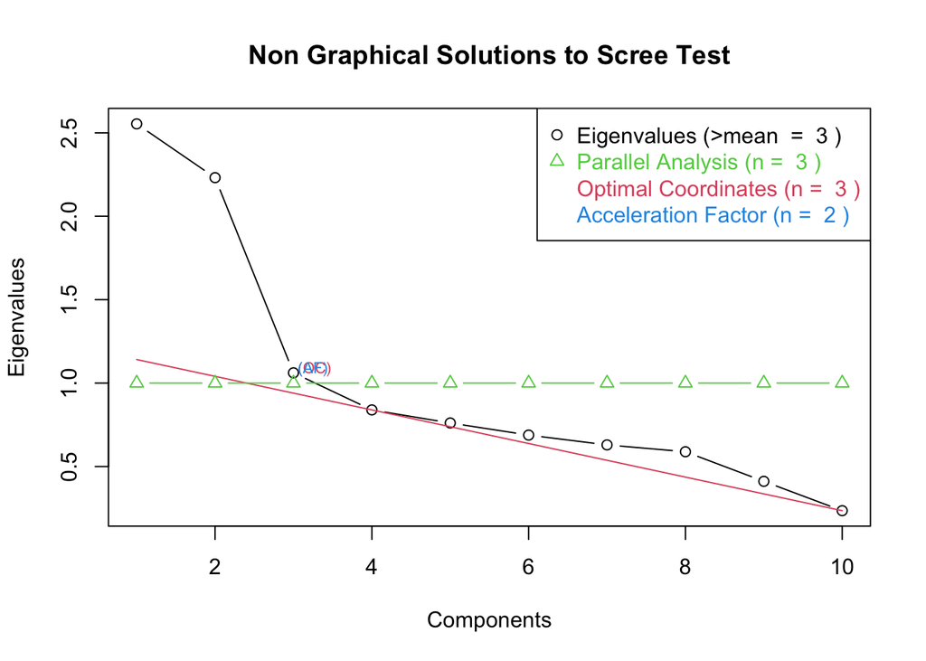

```r
library(nFactors)
nS <- nScree(x=ev$values) #get data for scree plot
plotnScree(nS)
```

- Most tests say we should extract 3 factors

## Models

```r
library(GPArotation)
fit1  = fa(efadata, nfactors = 3, n.iter = 100, fm = "ml")
fit1
```

```
## Factor Analysis with confidence intervals using method = fa(r = efadata, nfactors = 3, n.iter = 100, fm = "ml")
## Factor Analysis using method =  ml
## Call: fa(r = efadata, nfactors = 3, n.iter = 100, fm = "ml")
## Standardized loadings (pattern matrix) based upon correlation matrix
##           ML1   ML2   ML3   h2   u2 com
## imsmetn  0.75  0.02 -0.03 0.55 0.45 1.0
## imdfetn  0.93  0.00 -0.01 0.87 0.13 1.0
## impcntr  0.79 -0.02  0.04 0.64 0.36 1.0
## ipmodst -0.03  0.39  0.12 0.21 0.79 1.2
## imptrad -0.02  0.55 -0.03 0.29 0.71 1.0
## ipfrule  0.00  0.55 -0.03 0.29 0.71 1.0
## ipbhprp  0.01  0.65  0.02 0.43 0.57 1.0
## ipeqopt -0.01 -0.05  0.65 0.39 0.61 1.0
## ipudrst  0.06  0.08  0.47 0.27 0.73 1.1
## impenv   0.00  0.21  0.37 0.26 0.74 1.6
##
##                        ML1  ML2  ML3
## SS loadings           2.06 1.29 0.85
## Proportion Var        0.21 0.13 0.08
## Cumulative Var        0.21 0.33 0.42
## Proportion Explained  0.49 0.31 0.20
## Cumulative Proportion 0.49 0.80 1.00
##
##  With factor correlations of
##       ML1   ML2  ML3
## ML1  1.00 -0.19 0.13
## ML2 -0.19  1.00 0.45
## ML3  0.13  0.45 1.00
##
## Mean item complexity =  1.1
## Test of the hypothesis that 3 factors are sufficient.
##
## The degrees of freedom for the null model are  45  and the objective function was  2.35 with Chi Square of  11682.05
## The degrees of freedom for the model are 18  and the objective function was  0.03
##
## The root mean square of the residuals (RMSR) is  0.02
## The df corrected root mean square of the residuals is  0.03
##
## The harmonic number of observations is  4976 with the empirical chi square  130  with prob <  5.3e-19
## The total number of observations was  4976  with Likelihood Chi Square =  138.7  with prob <  1.1e-20
```

[output cut: 14 more lines]

```
## imdfetn  0.92  0.93  0.95 -0.02  0.00  0.02 -0.03 -0.01  0.01
## impcntr  0.77  0.79  0.81 -0.04 -0.02  0.00  0.01  0.04  0.07
## ipmodst -0.06 -0.03  0.00  0.34  0.39  0.44  0.07  0.12  0.17
## imptrad -0.04 -0.02  0.01  0.50  0.55  0.60 -0.08 -0.03  0.01
## ipfrule -0.03  0.00  0.02  0.51  0.55  0.59 -0.07 -0.03  0.02
## ipbhprp -0.02  0.01  0.03  0.59  0.65  0.70 -0.02  0.02  0.08
## ipeqopt -0.04 -0.01  0.01 -0.09 -0.05  0.00  0.59  0.65  0.71
## ipudrst  0.03  0.06  0.10  0.04  0.08  0.14  0.39  0.47  0.54
## impenv  -0.04  0.00  0.02  0.16  0.21  0.26  0.31  0.37  0.44
##
##  Interfactor correlations and bootstrapped confidence intervals
##          lower estimate upper
## ML1-ML2 -0.232    -0.19 -0.15
## ML1-ML3  0.087     0.13  0.16
## ML2-ML3  0.369     0.45  0.51
```

- Interpretation:
  - Acceptable cumulative var (0.42). It means that 42% of variance explained by 3 factors (should be > 0.5 to be good result)
  - RMSR is 0.02, which is very good
  - RMSEA index equals to 0.037, which is excellent (<.08 acceptable, <.05 excellent)
  - Tucker Lewis Index is excellent (0.974) (>.90 acceptable, >.95 excellent)
  - Mean item complexity 1.1, which is good
  - As for Proportion Var and Proportion Explained, everything is looking good.

```r
fit2 = fa(efadata, nfactors = 3, n.iter = 100, rotate = "varimax") #orthogonal rotation
fit2
```

```
## Factor Analysis with confidence intervals using method = fa(r = efadata, nfactors = 3, n.iter = 100, rotate = "varimax")
## Factor Analysis using method =  minres
## Call: fa(r = efadata, nfactors = 3, n.iter = 100, rotate = "varimax")
## Standardized loadings (pattern matrix) based upon correlation matrix
##           MR1   MR2  MR3   h2   u2 com
## imsmetn  0.74 -0.08 0.03 0.55 0.45 1.0
## imdfetn  0.92 -0.10 0.06 0.87 0.13 1.0
## impcntr  0.79 -0.09 0.09 0.64 0.36 1.1
## ipmodst -0.06  0.40 0.21 0.21 0.79 1.5
## imptrad -0.08  0.53 0.10 0.30 0.70 1.1
## ipfrule -0.06  0.52 0.11 0.29 0.71 1.1
## ipbhprp -0.06  0.63 0.18 0.44 0.56 1.2
## ipeqopt  0.05  0.10 0.61 0.39 0.61 1.1
## ipudrst  0.09  0.18 0.48 0.27 0.73 1.3
## impenv   0.01  0.29 0.42 0.26 0.74 1.8
##
##                        MR1  MR2  MR3
## SS loadings           2.04 1.27 0.89
## Proportion Var        0.20 0.13 0.09
## Cumulative Var        0.20 0.33 0.42
## Proportion Explained  0.49 0.30 0.21
## Cumulative Proportion 0.49 0.79 1.00
##
## Mean item complexity =  1.2
## Test of the hypothesis that 3 factors are sufficient.
##
## The degrees of freedom for the null model are  45  and the objective function was  2.35 with Chi Square of  11682.05
## The degrees of freedom for the model are 18  and the objective function was  0.03
##
## The root mean square of the residuals (RMSR) is  0.02
## The df corrected root mean square of the residuals is  0.03
##
## The harmonic number of observations is  4976 with the empirical chi square  128.31  with prob <  1.1e-18
## The total number of observations was  4976  with Likelihood Chi Square =  139.46  with prob <  8.1e-21
##
## Tucker Lewis Index of factoring reliability =  0.974
## RMSEA index =  0.037  and the 90 % confidence intervals are  0.031 0.043
## BIC =  -13.76
## Fit based upon off diagonal values = 1
## Measures of factor score adequacy
##                                                    MR1  MR2  MR3
## Correlation of (regression) scores with factors   0.94 0.78 0.72
## Multiple R square of scores with factors          0.89 0.61 0.51
## Minimum correlation of possible factor scores     0.79 0.21 0.02
##
##  Coefficients and bootstrapped confidence intervals
##           low   MR1 upper   low   MR2 upper  low  MR3 upper
## imsmetn  0.72  0.74  0.76 -0.10 -0.08 -0.06 0.01 0.03  0.05
## imdfetn  0.91  0.92  0.94 -0.12 -0.10 -0.09 0.04 0.06  0.08
## impcntr  0.77  0.79  0.81 -0.11 -0.09 -0.08 0.07 0.09  0.11
## ipmodst -0.08 -0.06 -0.03  0.36  0.40  0.44 0.17 0.21  0.25
## imptrad -0.10 -0.08 -0.05  0.49  0.53  0.58 0.07 0.10  0.14
## ipfrule -0.09 -0.06 -0.04  0.49  0.52  0.56 0.07 0.11  0.15
## ipbhprp -0.08 -0.06 -0.03  0.59  0.63  0.67 0.15 0.18  0.22
## ipeqopt  0.03  0.05  0.07  0.08  0.10  0.14 0.53 0.61  0.69
## ipudrst  0.07  0.09  0.12  0.14  0.18  0.22 0.43 0.48  0.54
## impenv  -0.02  0.01  0.03  0.25  0.29  0.33 0.37 0.42  0.46
```

- Rotation did not help as all indexes are the same as for previous model

```r
fit3 = fa(efadata, nfactors = 3, n.iter = 100, rotate = "oblimin")#oblique rotation
fit3
```

```
## Factor Analysis with confidence intervals using method = fa(r = efadata, nfactors = 3, n.iter = 100, rotate = "oblimin")
## Factor Analysis using method =  minres
## Call: fa(r = efadata, nfactors = 3, n.iter = 100, rotate = "oblimin")
## Standardized loadings (pattern matrix) based upon correlation matrix
##           MR1   MR2   MR3   h2   u2 com
## imsmetn  0.75  0.01 -0.03 0.55 0.45 1.0
## imdfetn  0.93  0.00 -0.01 0.87 0.13 1.0
## impcntr  0.79 -0.02  0.04 0.64 0.36 1.0
## ipmodst -0.03  0.38  0.12 0.21 0.79 1.2
## imptrad -0.02  0.56 -0.03 0.30 0.70 1.0
## ipfrule  0.00  0.55 -0.03 0.29 0.71 1.0
## ipbhprp  0.01  0.65  0.02 0.44 0.56 1.0
## ipeqopt -0.01 -0.05  0.64 0.39 0.61 1.0
## ipudrst  0.06  0.08  0.48 0.27 0.73 1.1
## impenv  -0.01  0.21  0.38 0.26 0.74 1.6
##
##                        MR1  MR2  MR3
## SS loadings           2.06 1.29 0.85
## Proportion Var        0.21 0.13 0.09
## Cumulative Var        0.21 0.33 0.42
## Proportion Explained  0.49 0.31 0.20
## Cumulative Proportion 0.49 0.80 1.00
##
##  With factor correlations of
##       MR1   MR2  MR3
## MR1  1.00 -0.19 0.13
## MR2 -0.19  1.00 0.45
## MR3  0.13  0.45 1.00
##
## Mean item complexity =  1.1
## Test of the hypothesis that 3 factors are sufficient.
##
## The degrees of freedom for the null model are  45  and the objective function was  2.35 with Chi Square of  11682.05
## The degrees of freedom for the model are 18  and the objective function was  0.03
##
## The root mean square of the residuals (RMSR) is  0.02
## The df corrected root mean square of the residuals is  0.03
##
## The harmonic number of observations is  4976 with the empirical chi square  128.31  with prob <  1.1e-18
## The total number of observations was  4976  with Likelihood Chi Square =  139.46  with prob <  8.1e-21
```

[output cut: 14 more lines]

```
## imdfetn  0.92  0.93  0.95 -0.02  0.00  0.02 -0.03 -0.01  0.02
## impcntr  0.77  0.79  0.81 -0.04 -0.02  0.01  0.02  0.04  0.06
## ipmodst -0.06 -0.03  0.00  0.33  0.38  0.43  0.07  0.12  0.17
## imptrad -0.05 -0.02  0.01  0.50  0.56  0.60 -0.08 -0.03  0.02
## ipfrule -0.03  0.00  0.02  0.50  0.55  0.60 -0.08 -0.03  0.03
## ipbhprp -0.02  0.01  0.03  0.60  0.65  0.70 -0.01  0.02  0.06
## ipeqopt -0.04 -0.01  0.01 -0.09 -0.05  0.00  0.58  0.64  0.70
## ipudrst  0.03  0.06  0.09  0.03  0.08  0.13  0.40  0.48  0.56
## impenv  -0.04 -0.01  0.02  0.16  0.21  0.26  0.31  0.38  0.45
##
##  Interfactor correlations and bootstrapped confidence intervals
##          lower estimate upper
## MR1-MR2 -0.234    -0.19 -0.15
## MR1-MR3  0.093     0.13  0.17
## MR2-MR3  0.375     0.45  0.52
```

- Rotation did not help as all indexes are the same as for previous model

## Visualisation

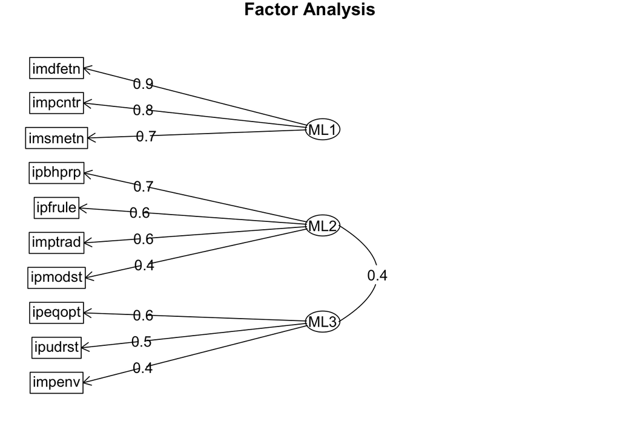

```r
fa.diagram(fit1)
```

- M1: xenophobia
  - imsmetn - ALLOW MANY/FEW IMMIGRANTS OF SAME RACE/ETHNIC GROUP ASMAJORITY
  - imdfetn - ALLOW MANY/FEW IMMIGRANTS OF DIFFERENT RACE/ETHNIC GROUP FROM MAJORITY
  - impcntr - ALLOW MANY/FEW IMMIGRANTS FROM POORER COUNTRIES OUTSIDE EUROPE
- M2: conservation
  - ipmodst - IMPORTANT TO BE HUMBLE AND MODEST, NOT DRAW ATTENTION
  - imptrad - IMPORTANT TO FOLLOW TRADITIONS AND CUSTOMS
  - ipfrule - IMPORTANT TO DO WHAT IS TOLD AND FOLLOW RULES
  - ipbhprp - IMPORTANT TO BEHAVE PROPERLY
- M3: universalism
  - ipeqopt - IMPORTANT THAT PEOPLE ARE TREATED EQUALLY AND HAVE EQUAL OPPORTUNITIES
  - ipudrst - IMPORTANT TO UNDERSTAND DIFFERENT PEOPLE
  - impenv - IMPORTANT TO CARE FOR NATURE AND ENVIRONMENT

# CFA

- Using CFA check if the established model matches the data

## Specification of the model

```r
library(lavaan)

S.model1 <- '
xenophobia =~ imsmetn + imdfetn + impcntr
conservation =~ ipmodst + imptrad + ipfrule + ipbhprp
universalism =~ ipeqopt + ipudrst + impenv
'
```

## Run CFA

```r
fit1 = cfa(S.model1, data = benelux)
summary(fit1, standardized=TRUE, fit.measures=TRUE, modindices=TRUE)
```

```
## lavaan 0.6-12 ended normally after 42 iterations
##
##   Estimator                                         ML
##   Optimization method                           NLMINB
##   Number of model parameters                        23
##
##   Number of observations                          4976
##
## Model Test User Model:
##
##   Test statistic                               267.058
##   Degrees of freedom                                32
##   P-value (Chi-square)                           0.000
##
## Model Test Baseline Model:
##
##   Test statistic                             11694.190
##   Degrees of freedom                                45
##   P-value                                        0.000
##
## User Model versus Baseline Model:
##
##   Comparative Fit Index (CFI)                    0.980
##   Tucker-Lewis Index (TLI)                       0.972
##
## Loglikelihood and Information Criteria:
##
##   Loglikelihood user model (H0)             -67380.038
##   Loglikelihood unrestricted model (H1)     -67246.509
##
##   Akaike (AIC)                              134806.076
##   Bayesian (BIC)                            134955.861
##   Sample-size adjusted Bayesian (BIC)       134882.775
##
## Root Mean Square Error of Approximation:
##
##   RMSEA                                          0.038
##   90 Percent confidence interval - lower         0.034
##   90 Percent confidence interval - upper         0.043
##   P-value RMSEA <= 0.05                          1.000
```

[output cut: 104 more lines]

```
## 51      imptrad ~~ ipfrule 12.499  0.090   0.090    0.068    0.068
## 52      imptrad ~~ ipbhprp  7.881 -0.072  -0.072   -0.070   -0.070
## 53      imptrad ~~ ipeqopt 31.123 -0.086  -0.086   -0.095   -0.095
## 54      imptrad ~~ ipudrst 20.214 -0.075  -0.075   -0.076   -0.076
## 55      imptrad ~~  impenv 91.156  0.157   0.157    0.165    0.165
## 56      ipfrule ~~ ipbhprp  5.822  0.062   0.062    0.062    0.062
## 57      ipfrule ~~ ipeqopt  4.817 -0.034  -0.034   -0.038   -0.038
## 58      ipfrule ~~ ipudrst  1.706  0.022   0.022    0.022    0.022
## 59      ipfrule ~~  impenv  5.548 -0.038  -0.038   -0.041   -0.041
## 60      ipbhprp ~~ ipeqopt  0.767 -0.012  -0.012   -0.017   -0.017
## 61      ipbhprp ~~ ipudrst  3.041 -0.025  -0.025   -0.034   -0.034
## 62      ipbhprp ~~  impenv  3.631  0.027   0.027    0.037    0.037
## 63      ipeqopt ~~ ipudrst 27.493  0.087   0.087    0.131    0.131
## 64      ipeqopt ~~  impenv  0.007  0.001   0.001    0.002    0.002
## 65      ipudrst ~~  impenv 28.454 -0.097  -0.097   -0.139   -0.139
```

- Tucker-Lewis Index (TLI) is excellent (0.97)
- Comparative Fit Index (CFI) is also excellent (0.98)
- RMSEA index equals to 0.038 (<.08 acceptable, <.05 excellent), which excellent
- SRMR equals to 0.028, which is excellent

-> In accordance with above indexes, the model is good, but

- P-value of Chi-square equals to 0.000, which says to us that the model is different from data, but all important indexes confirmed that the model is good, thus, we can be sure in this model.
- As for factor loadings, all of them are significant according to p-values (0.000). (Look at Latent Variables section)

## Find problematic parameteris by MI and EPC

- MI (threshold is 3.84 - should be less than this value) shows how Chi-square would change if we estimate some additional parameters.
- EPC shows us the value to what the corresponding parameter equals to (correlation). Standardized EPC ≥ |0.2| indicate problematic misspecifications.

```r
mi_1 <- modindices(fit1)
mi_1[mi_1$mi > 3.84, 1:5]
```

```
##             lhs op     rhs     mi    epc
## 28   xenophobia =~ imptrad  4.459 -0.069
## 30   xenophobia =~ ipbhprp  4.902  0.066
## 32   xenophobia =~ ipudrst 19.251  0.111
## 33   xenophobia =~  impenv 36.147 -0.152
## 37 conservation =~ ipeqopt 30.672 -0.239
## 38 conservation =~ ipudrst  8.889 -0.139
## 39 conservation =~  impenv 70.956  0.396
## 42 universalism =~ impcntr  5.432  0.052
## 43 universalism =~ ipmodst 11.286  0.229
## 45 universalism =~ ipfrule  6.504 -0.182
## 57      imdfetn ~~ ipmodst  6.511 -0.023
## 64      impcntr ~~ ipmodst  9.259  0.031
## 68      impcntr ~~ ipeqopt 12.135  0.025
## 72      ipmodst ~~ ipfrule 18.895 -0.103
## 74      ipmodst ~~ ipeqopt  7.044  0.039
## 75      ipmodst ~~ ipudrst 22.216  0.076
## 76      ipmodst ~~  impenv  5.354 -0.037
## 77      imptrad ~~ ipfrule 12.499  0.090
## 78      imptrad ~~ ipbhprp  7.881 -0.072
## 79      imptrad ~~ ipeqopt 31.123 -0.086
## 80      imptrad ~~ ipudrst 20.214 -0.075
## 81      imptrad ~~  impenv 91.156  0.157
## 82      ipfrule ~~ ipbhprp  5.822  0.062
## 83      ipfrule ~~ ipeqopt  4.817 -0.034
## 85      ipfrule ~~  impenv  5.548 -0.038
## 89      ipeqopt ~~ ipudrst 27.493  0.087
## 91      ipudrst ~~  impenv 28.454 -0.097
```

- The highest modification indices (correlations) have parameters:
  - imptrad ~~ impenv
  - and others

## Improve the model

```r
S.model2 <- '
xenophobia =~ imsmetn + imdfetn + impcntr
conservation =~ ipmodst + imptrad + ipfrule + ipbhprp
universalism =~ ipeqopt + ipudrst + impenv
imptrad ~~  impenv
'
```

```r
fit2 = cfa(S.model2, data = benelux)
summary(fit2, standardized=TRUE, fit.measures=TRUE, modindices=TRUE)
```

```
## lavaan 0.6-12 ended normally after 44 iterations
##
##   Estimator                                         ML
##   Optimization method                           NLMINB
##   Number of model parameters                        24
##
##   Number of observations                          4976
##
## Model Test User Model:
##
##   Test statistic                               175.359
##   Degrees of freedom                                31
##   P-value (Chi-square)                           0.000
##
## Model Test Baseline Model:
##
##   Test statistic                             11694.190
##   Degrees of freedom                                45
##   P-value                                        0.000
##
## User Model versus Baseline Model:
##
##   Comparative Fit Index (CFI)                    0.988
##   Tucker-Lewis Index (TLI)                       0.982
##
## Loglikelihood and Information Criteria:
##
##   Loglikelihood user model (H0)             -67334.189
##   Loglikelihood unrestricted model (H1)     -67246.509
##
##   Akaike (AIC)                              134716.378
##   Bayesian (BIC)                            134872.675
##   Sample-size adjusted Bayesian (BIC)       134796.411
##
## Root Mean Square Error of Approximation:
##
##   RMSEA                                          0.031
##   90 Percent confidence interval - lower         0.026
##   90 Percent confidence interval - upper         0.035
##   P-value RMSEA <= 0.05                          1.000
```

[output cut: 105 more lines]

```
## 50      ipmodst ~~  impenv  0.562 -0.012  -0.012   -0.012   -0.012
## 51      imptrad ~~ ipfrule 22.965  0.120   0.120    0.090    0.090
## 52      imptrad ~~ ipbhprp  3.609 -0.048  -0.048   -0.047   -0.047
## 53      imptrad ~~ ipeqopt 11.082 -0.052  -0.052   -0.057   -0.057
## 54      imptrad ~~ ipudrst  2.878 -0.029  -0.029   -0.029   -0.029
## 55      ipfrule ~~ ipbhprp  1.151  0.030   0.030    0.030    0.030
## 56      ipfrule ~~ ipeqopt  5.488 -0.036  -0.036   -0.041   -0.041
## 57      ipfrule ~~ ipudrst  1.397  0.020   0.020    0.021    0.021
## 58      ipfrule ~~  impenv  1.013 -0.016  -0.016   -0.017   -0.017
## 59      ipbhprp ~~ ipeqopt  1.916 -0.019  -0.019   -0.028   -0.028
## 60      ipbhprp ~~ ipudrst  5.890 -0.035  -0.035   -0.048   -0.048
## 61      ipbhprp ~~  impenv 26.693  0.075   0.075    0.102    0.102
## 62      ipeqopt ~~ ipudrst  7.433  0.051   0.051    0.078    0.078
## 63      ipeqopt ~~  impenv  2.296  0.026   0.026    0.040    0.040
## 64      ipudrst ~~  impenv 16.960 -0.075  -0.075   -0.107   -0.107
```

Let us see whether indexes become better or not after adding correlations among some variables to structure of our model:

- Tucker-Lewis Index (TLI) becomes even better (0.98)
- Comparative Fit Index (CFI) is also become even better 0.99
- RMSEA index equals becomes smaller: for this model it equals 0.031, for previous model it was 0.038.
- SRMR equals to 0.025, for previous model it was 0.028, thus, also become better!
- To sum up, model become better after adding correlation among variables that is not fully explained by one common factor. However, to be sure that the second model is significantly better than the first one we should run anova.

## ANOVA

```r
anova(fit1, fit2)
```

```
## Chi-Squared Difference Test
##
##      Df    AIC    BIC  Chisq Chisq diff Df diff Pr(>Chisq)
## fit2 31 134716 134873 175.36
## fit1 32 134806 134956 267.06     91.698       1  < 2.2e-16 ***
## ---
## Signif. codes:  0 '***' 0.001 '**' 0.01 '*' 0.05 '.' 0.1 ' ' 1
```

- Anova result shows that the second model is significantly better than the first one. It means that the second model explains data better, than the first one.
- We have lost 1 degree of freedom
- Chi-square’s difference is 91, which is really high
- Thus, the second model is better

# OLS

Now let’s explore the association between main socio-demographic characteristics and created latent variables.

## Saving factor scores

```r
benelux[,16:18] <- lavPredict(fit2, method = "regression")
colnames(benelux)[16:18] <- c("xenophobia", "conservation","universalism")
```

## Models

```r
benelux$gndr <- factor(benelux$gndr, levels = 1:2, labels = c("Male", "Female"))
```

### Xenophobia

```r
labs <- c("Constant","Gender(Female)", "Year of birth", "Education years")

mod1 <- lm(xenophobia~gndr+yrbrn+eduyrs, data = benelux)
library(sjPlot)
tab_model(mod1, pred.labels = labs, dv.labels = "Xenophobia")
```

|  | Xenophobia |  |  |
| --- | --- | --- | --- |
| Predictors | Estimates | CI | p |
| Constant | 7.56 | 5.78 – 9.34 | **<0.001** |
| Gender(Female) | 0.01 | -0.02 – 0.04 | 0.455 |
| Year of birth | -0.00 | -0.00 – -0.00 | **<0.001** |
| Education years | -0.03 | -0.03 – -0.03 | **<0.001** |
| Observations | 4976 |  |  |
| R<sup>2</sup> / R<sup>2</sup> adjusted | 0.065 / 0.064 |  |  |

- Men and women do not significantly differ in levels of xenophobia (p-value = 0.45)
- The relationship between year of birth and xenophobia is significant (p-values < 0.001) and negative. For each additional increase in year of birth the predicted level of xenophobia is 0.004 lower, on average, holding everything else constant.
- The relationship between education and xenophobia is significant (p-values < 0.001) and negative. For each additional year of education the predicted level of xenophobia is 0.03 lower, on average, holding everything else constant.
- Adjusted R-squared is 0.064, it means that 6.4% of variance in xenophobia can be explained by the the model.

### Conservation

```r
mod2 <-  lm(conservation~gndr+yrbrn+eduyrs, data = benelux)
tab_model(mod2, pred.labels = labs, dv.labels = "Conservation")
```

|  | Conservation |  |  |
| --- | --- | --- | --- |
| Predictors | Estimates | CI | p |
| Constant | -15.35 | -16.85 – -13.85 | **<0.001** |
| Gender(Female) | 0.01 | -0.02 – 0.03 | 0.647 |
| Year of birth | 0.01 | 0.01 – 0.01 | **<0.001** |
| Education years | 0.01 | 0.01 – 0.02 | **<0.001** |
| Observations | 4976 |  |  |
| R<sup>2</sup> / R<sup>2</sup> adjusted | 0.098 / 0.097 |  |  |

- Men and women do not significantly differ in levels of conservation (p-value = 0.65)
- The relationship between year of birth and conservation is significant (p-values < 0.001) and positive. For each additional increase in year of birth the predicted level of conservation is 0.01 higher, on average, holding everything else constant.
- The relationship between education and conservation is significant (p-values < 0.001) and positive. For each additional year of education the predicted level of conservation is 0.01 higher, on average, holding everything else constant.
- Adjusted R-squared is 0.097, it means that 9.7% of variance in conservation can be explained by the the model.

### Universalism

```r
mod3 <- lm(universalism~gndr+yrbrn+eduyrs, data = benelux)
tab_model(mod3, pred.labels = labs, dv.labels = "Universalism")
```

|  | Universalism |  |  |
| --- | --- | --- | --- |
| Predictors | Estimates | CI | p |
| Constant | -6.56 | -7.77 – -5.34 | **<0.001** |
| Gender(Female) | -0.03 | -0.06 – -0.01 | **0.002** |
| Year of birth | 0.00 | 0.00 – 0.00 | **<0.001** |
| Education years | -0.01 | -0.01 – -0.00 | **<0.001** |
| Observations | 4976 |  |  |
| R<sup>2</sup> / R<sup>2</sup> adjusted | 0.024 / 0.024 |  |  |

- For females the predicted level of universalism is 0.03 lower, than for males on average, holding everything else constant (p-value = 0.002).
- The relationship between year of birth and universalism is significant (p-value < 0.001) and positive. For each additional increase in year of birth the predicted level of universalism is 0.003 higher, on average, holding everything else constant.
- The relationship between education and universalism is significant (p-values < 0.001) and negative. For each additional year of education the predicted level of universalism is 0.005 lower, on average, holding everything else constant.
- Adjusted R-squared is 0.024, it means that only 2.4% of variance in universalism can be explained by the the model.